# Chapter 2 Homework

James Livingstone

September 20, 2022

# 1.

Table of Summary Statistics

```r
descr(gasturbine, RPM, stats = "common", transpose = T)
```

```
## Descriptive Statistics
## gasturbine$RPM
## N: 67
##
##                Mean   Std.Dev       Min    Median        Max   N.Valid   Pct.Valid
## --------- --------- --------- --------- --------- ---------- --------- -----------
##       RPM   8326.64   7023.31   3000.00   5100.00   33000.00     67.00      100.00
```

```r
descr(gasturbine, CPRATIO, stats = "common", transpose = T)
```

```
## Descriptive Statistics
## gasturbine$CPRATIO
## N: 67
##
##                  Mean   Std.Dev    Min   Median     Max   N.Valid   Pct.Valid
## ------------- ------- --------- ------ -------- ------- --------- -----------
##       CPRATIO   14.72      4.24   6.60    14.60   35.00     67.00      100.00
```

```r
descr(gasturbine, INLET_TEMP, stats = "common", transpose = T)
```

```
## Descriptive Statistics
## gasturbine$INLET_TEMP
## N: 67
##
##                       Mean   Std.Dev      Min    Median       Max   N.Valid   Pct.Valid
## ---------------- --------- --------- -------- --------- --------- --------- -----------
##       INLET_TEMP   1174.31    137.43   888.00   1149.00   1427.00     67.00      100.00
```

```r
descr(gasturbine, EXH_TEMP, stats = "common", transpose = T)
```

```
## Descriptive Statistics
## gasturbine$EXH_TEMP
## N: 67
##
##                    Mean   Std.Dev      Min   Median      Max   N.Valid   Pct.Valid
## -------------- -------- --------- -------- -------- -------- --------- -----------
##       EXH_TEMP   536.09     44.14   444.00   532.00   626.00     67.00      100.00
```

```r
descr(gasturbine, AIRFLOW, stats = "common", transpose = T)
```

```
## Descriptive Statistics
## gasturbine$AIRFLOW
## N: 67
##
##                   Mean   Std.Dev    Min   Median      Max   N.Valid   Pct.Valid
## ------------- -------- --------- ------ -------- -------- --------- -----------
##       AIRFLOW   240.79    226.71   3.00   172.00   737.00     67.00      100.00
```

```r
descr(gasturbine, POWER, stats = "common", transpose = T)
```

```
## Descriptive Statistics
## gasturbine$POWER
## N: 67
##
##                   Mean    Std.Dev      Min     Median         Max   N.Valid   Pct.Valid
## ----------- ---------- ---------- -------- ---------- ----------- --------- -----------
##       POWER   87205.82   94472.50   486.00   52600.00   334000.00     67.00      100.00
```

```r
descr(gasturbine, HEATRATE, stats = "common", transpose = T)
```

```
## Descriptive Statistics
## gasturbine$HEATRATE
## N: 67
##
##                      Mean   Std.Dev       Min     Median        Max   N.Valid   Pct.Valid
## -------------- ---------- --------- --------- ---------- ---------- --------- -----------
##       HEATRATE   11066.43   1594.96   8714.00   10656.00   16243.00     67.00      100.00
```

# 2.

Scatterplots

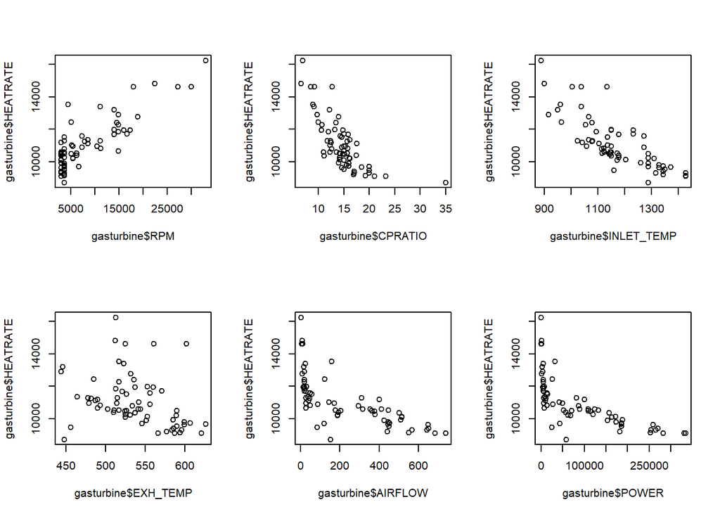

```r
par(mfrow = c(2,3))
plot(gasturbine$RPM, gasturbine$HEATRATE)
plot(gasturbine$CPRATIO, gasturbine$HEATRATE)
plot(gasturbine$INLET_TEMP, gasturbine$HEATRATE)
plot(gasturbine$EXH_TEMP, gasturbine$HEATRATE)
plot(gasturbine$AIRFLOW, gasturbine$HEATRATE)
plot(gasturbine$POWER, gasturbine$HEATRATE)
```

# 3.

```r
RPM_model = lm(HEATRATE ~ RPM, data = gasturbine)
summary(RPM_model)
```

```
##
## Call:
## lm(formula = HEATRATE ~ RPM, data = gasturbine)
##
## Residuals:
##     Min      1Q  Median      3Q     Max
## -1679.9  -590.8  -112.5   442.0  3195.2
##
## Coefficients:
##              Estimate Std. Error t value Pr(>|t|)
## (Intercept) 9.470e+03  1.641e+02   57.73   <2e-16 ***
## RPM         1.917e-01  1.511e-02   12.69   <2e-16 ***
## ---
## Signif. codes:  0 '***' 0.001 '**' 0.01 '*' 0.05 '.' 0.1 ' ' 1
##
## Residual standard error: 862 on 65 degrees of freedom
## Multiple R-squared:  0.7123, Adjusted R-squared:  0.7079
## F-statistic:   161 on 1 and 65 DF,  p-value: < 2.2e-16
```

```r
CPRATIO_model = lm(HEATRATE ~ CPRATIO, data = gasturbine)
summary(CPRATIO_model)
```

```
##
## Call:
## lm(formula = HEATRATE ~ CPRATIO, data = gasturbine)
##
## Residuals:
##     Min      1Q  Median      3Q     Max
## -1705.4  -749.2  -226.9   469.8  3247.7
##
## Coefficients:
##             Estimate Std. Error t value Pr(>|t|)
## (Intercept) 15130.22     484.21   31.25  < 2e-16 ***
## CPRATIO      -276.11      31.63   -8.73 1.49e-12 ***
## ---
## Signif. codes:  0 '***' 0.001 '**' 0.01 '*' 0.05 '.' 0.1 ' ' 1
##
## Residual standard error: 1090 on 65 degrees of freedom
## Multiple R-squared:  0.5397, Adjusted R-squared:  0.5326
## F-statistic:  76.2 on 1 and 65 DF,  p-value: 1.486e-12
```

```r
INLET_TEMP_model = lm(HEATRATE ~ INLET_TEMP, data = gasturbine)
summary(INLET_TEMP_model)
```

```
##
## Call:
## lm(formula = HEATRATE ~ INLET_TEMP, data = gasturbine)
##
## Residuals:
##     Min      1Q  Median      3Q     Max
## -1730.4  -715.6   -78.2   454.5  3181.0
##
## Coefficients:
##               Estimate Std. Error t value Pr(>|t|)
## (Intercept) 21976.5731  1019.8040   21.55  < 2e-16 ***
## INLET_TEMP     -9.2907     0.8626  -10.77 4.29e-16 ***
## ---
## Signif. codes:  0 '***' 0.001 '**' 0.01 '*' 0.05 '.' 0.1 ' ' 1
##
## Residual standard error: 963.1 on 65 degrees of freedom
## Multiple R-squared:  0.6409, Adjusted R-squared:  0.6354
## F-statistic:   116 on 1 and 65 DF,  p-value: 4.288e-16
```

# 4.

Assess the Fit

RPM: S = 862, CV = 7.8%, r= 0.84, r^2 = 71.2%, t = 12.69, p-value < 0.001

CPRATIO: S = 1090, CV = 9.9%, r= -0.73, r^2 = 54.0%, t = -8.73, p-value < 0.001

INLET_TEMP: S = 963.1, CV = 8.7%, r= -0.8, r^2 = 64.1%, t = -10.77, p-value < 0.001

The best model for HEATRATE is RPM vs. HEATRATE model because it has comparatively the smallest S value, the lowest CV value, a level of significance with its p-value being < 0.001, and the highest r^2 value.

HEATRATE = 9470 + 0.1917(RPM)

If the gasturbine is at 0 RPM, we would expect the HEATRATE to be 9470. For every 1 RPM increase we would expect a 0.1917 increase in the HEATRATE.

71.2% of the variability in HEATRATE can be explained by a linear relationship with the level of RPM.

There is enough evidence to conclude that the amount of RPM has a significant effect on HEATRATE.

```r
sigma(RPM_model) / mean(gasturbine$HEATRATE) *100 #CV
```

```
## [1] 7.789387
```

```r
sigma(CPRATIO_model) / mean(gasturbine$HEATRATE) *100 #CV
```

```
## [1] 9.853493
```

```r
sigma(INLET_TEMP_model) / mean(gasturbine$HEATRATE) *100 #CV
```

```
## [1] 8.703183
```

```r
gasturbine %>%
  select(RPM, HEATRATE) %>%
  as.matrix() %>%
  rcorr()
```

```
##           RPM HEATRATE
## RPM      1.00     0.84
## HEATRATE 0.84     1.00
##
## n= 67
##
##
## P
##          RPM HEATRATE
## RPM           0
## HEATRATE  0
```

```r
gasturbine %>%
  select (CPRATIO, HEATRATE) %>%
  as.matrix() %>%
  rcorr()
```

```
##          CPRATIO HEATRATE
## CPRATIO     1.00    -0.73
## HEATRATE   -0.73     1.00
##
## n= 67
##
##
## P
##          CPRATIO HEATRATE
## CPRATIO           0
## HEATRATE  0
```

```r
gasturbine %>%
  select(INLET_TEMP, HEATRATE) %>%
  as.matrix() %>%
  rcorr()
```

```
##            INLET_TEMP HEATRATE
## INLET_TEMP        1.0     -0.8
## HEATRATE         -0.8      1.0
##
## n= 67
##
##
## P
##            INLET_TEMP HEATRATE
## INLET_TEMP             0
## HEATRATE    0
```

# 5.

Prediction Interval

PI: (8884.723, 12356.26)

We are 95% confident that when the gasturbine has 6000 RPM, the HEATRATE is between 8884.723 and 12356.26

```r
predict(RPM_model, newdata = data.frame(RPM = 6000),
        interval = "prediction", level = 0.95)
```

```
##        fit      lwr      upr
## 1 10620.49 8884.723 12356.26
```

# 6.

Confidence Interval

CI: (10398.76, 10842.22)

We are 95% confident that when the gasturbine has 6000 RPM, the mean HEATRATE is between 10398.76 and 10842.22

```r
predict(RPM_model, newdata = data.frame(RPM = 6000),
        interval = "confidence", level = 0.95)
```

```
##        fit      lwr      upr
## 1 10620.49 10398.76 10842.22
```